# Predicting Developer Remote Working Status

# Exploring and prepping the data

The dataset originally from the [Stack Overflow Developer Survey](https://insights.stackoverflow.com/survey/2021), was provided in [chapter 2 of Julia Sigle’s Supervised Machine Learning Case Studies in R](https://supervised-ml-course.netlify.app). Lets explore the dataset, we begin by checking how many remote and non-remote developers there are and a breakdown by country.

```r
# Quick look at the dataset:
glimpse(stack_overflow)
```

```
## Rows: 6,991
## Columns: 22
## $ respondent                           <dbl> 3, 15, 18, 19, 26, 55, 62, 71, 73…
## $ country                              <chr> "United Kingdom", "United Kingdom…
## $ salary                               <dbl> 113750.000, 100000.000, 130000.00…
## $ years_coded_job                      <dbl> 20, 20, 20, 3, 16, 4, 1, 1, 20, 2…
## $ open_source                          <lgl> TRUE, FALSE, TRUE, FALSE, FALSE, …
## $ hobby                                <lgl> TRUE, TRUE, TRUE, TRUE, TRUE, FAL…
## $ company_size_number                  <dbl> 10000, 5000, 1000, 10000, 10000, …
## $ remote                               <chr> "Not remote", "Remote", "Remote",…
## $ career_satisfaction                  <dbl> 8, 8, 9, 5, 7, 9, 5, 8, 8, 10, 7,…
## $ data_scientist                       <lgl> FALSE, FALSE, FALSE, FALSE, FALSE…
## $ database_administrator               <lgl> FALSE, FALSE, FALSE, FALSE, FALSE…
## $ desktop_applications_developer       <lgl> FALSE, FALSE, FALSE, FALSE, FALSE…
## $ developer_with_stats_math_background <lgl> FALSE, FALSE, FALSE, FALSE, FALSE…
## $ dev_ops                              <lgl> FALSE, FALSE, TRUE, FALSE, FALSE,…
## $ embedded_developer                   <lgl> FALSE, TRUE, TRUE, FALSE, FALSE, …
## $ graphic_designer                     <lgl> FALSE, FALSE, FALSE, FALSE, FALSE…
## $ graphics_programming                 <lgl> FALSE, FALSE, FALSE, FALSE, FALSE…
## $ machine_learning_specialist          <lgl> FALSE, FALSE, FALSE, FALSE, FALSE…
## $ mobile_developer                     <lgl> FALSE, FALSE, FALSE, FALSE, FALSE…
## $ quality_assurance_engineer           <lgl> FALSE, FALSE, TRUE, FALSE, FALSE,…
## $ systems_administrator                <lgl> FALSE, FALSE, FALSE, FALSE, FALSE…
## $ web_developer                        <lgl> FALSE, FALSE, TRUE, TRUE, TRUE, T…
```

```r
# First count for remote
stack_overflow %>%
  count(remote, sort = TRUE)
```

```
## # A tibble: 2 × 2
##   remote         n
##   <chr>      <int>
## 1 Not remote  6273
## 2 Remote       718
```

```r
# Then by country
stack_overflow %>%
  count(country, sort = TRUE)
```

```
## # A tibble: 5 × 2
##   country            n
##   <chr>          <int>
## 1 United States   3486
## 2 United Kingdom  1270
## 3 Germany          950
## 4 India            666
## 5 Canada           619
```

Lets plot a boxplot of the employment type and years of professional coding experience.

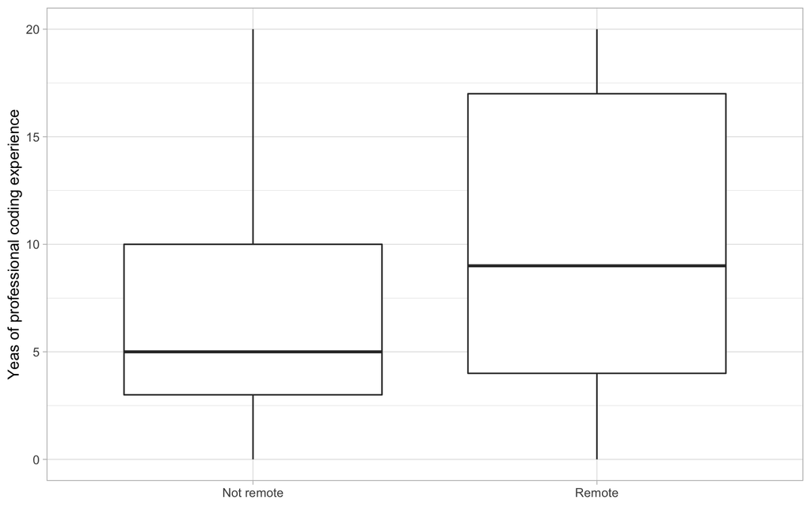

```r
ggplot(stack_overflow, aes(remote,years_coded_job))+
  geom_boxplot()+
  labs(x=NULL,
       y="Yeas of professional coding experience")+
  theme_light()
```

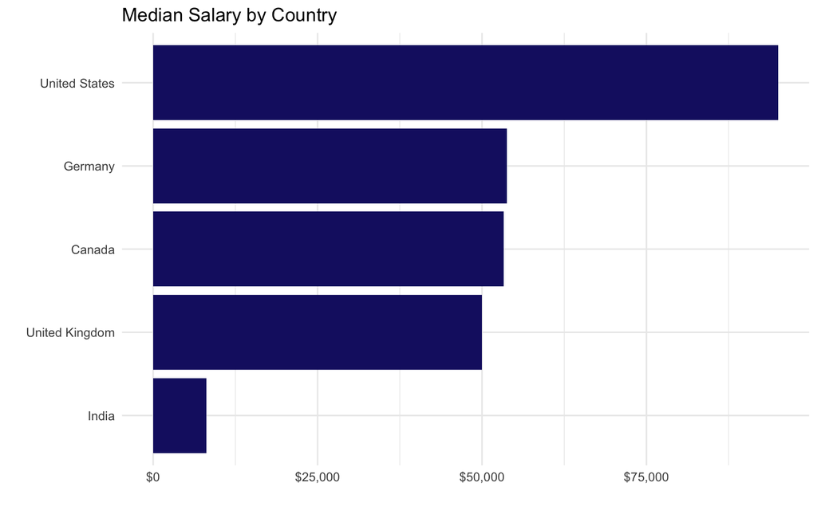

```r
stack_overflow %>%
  group_by(country) %>%
  summarise(salary=median(salary)) %>%
  mutate(country=fct_reorder(country,salary)) %>%
  ggplot(aes(country,salary))+
  geom_col(fill="midnightblue")+
  theme_minimal()+
  coord_flip()+
  xlab("")+
  ylab("")+
  scale_y_continuous(labels = scales::dollar_format())+
  ggtitle("Median Salary by Country")
```

## Training and testing data

```r
# make character variables into factors
stack_overflow <- stack_overflow %>%
  mutate(remote=factor(remote, levels = c("Remote","Not remote"))) %>%
  mutate_if(is.character,factor)
# Create stack_select dataset
stack_select <-  stack_overflow %>%
  select(-respondent)
# Split the data into training and testing sets
set.seed(1234)
stack_split <- initial_split(stack_select, strata=remote)
stack_train <- training(stack_split)
stack_test <- testing(stack_split)
# Take a quick look at the training data:
glimpse(stack_train)
```

```
## Rows: 5,242
## Columns: 21
## $ country                              <fct> United Kingdom, United States, Ge…
## $ salary                               <dbl> 113750.000, 175000.000, 64516.129…
## $ years_coded_job                      <dbl> 20, 16, 4, 1, 13, 7, 17, 1, 1, 10…
## $ open_source                          <lgl> TRUE, FALSE, FALSE, FALSE, FALSE,…
## $ hobby                                <lgl> TRUE, TRUE, FALSE, TRUE, TRUE, TR…
## $ company_size_number                  <dbl> 10000, 10000, 1000, 5000, 20, 20,…
## $ remote                               <fct> Not remote, Not remote, Not remot…
## $ career_satisfaction                  <dbl> 8, 7, 9, 5, 7, 8, 9, 10, 5, 8, 7,…
## $ data_scientist                       <lgl> FALSE, FALSE, FALSE, FALSE, FALSE…
## $ database_administrator               <lgl> FALSE, FALSE, FALSE, FALSE, FALSE…
## $ desktop_applications_developer       <lgl> FALSE, FALSE, FALSE, FALSE, FALSE…
## $ developer_with_stats_math_background <lgl> FALSE, FALSE, FALSE, FALSE, FALSE…
## $ dev_ops                              <lgl> FALSE, FALSE, FALSE, FALSE, FALSE…
## $ embedded_developer                   <lgl> FALSE, FALSE, FALSE, FALSE, FALSE…
## $ graphic_designer                     <lgl> FALSE, FALSE, FALSE, FALSE, FALSE…
## $ graphics_programming                 <lgl> FALSE, FALSE, FALSE, FALSE, FALSE…
## $ machine_learning_specialist          <lgl> FALSE, FALSE, FALSE, FALSE, FALSE…
## $ mobile_developer                     <lgl> FALSE, FALSE, FALSE, FALSE, FALSE…
## $ quality_assurance_engineer           <lgl> FALSE, FALSE, FALSE, FALSE, FALSE…
## $ systems_administrator                <lgl> FALSE, FALSE, FALSE, FALSE, FALSE…
## $ web_developer                        <lgl> FALSE, TRUE, TRUE, TRUE, TRUE, FA…
```

## Dealing with unmbalanced data

In order to address the class imbalance of our dataset, we can use downsampling.

```r
stack_overflow %>%
  count(remote)
```

```
## # A tibble: 2 × 2
##   remote         n
##   <fct>      <int>
## 1 Remote       718
## 2 Not remote  6273
```

Downsampling removes some of the majority class so that it has less effect on the predictive model. It also randomly removes examples from the majority class until it is equal to the minority class,in size. Here we will implement downsampling using the step_downsample() function from the recipes package. Downsampling is performed on the training dataset:

```r
stack_recipe <- recipe(remote~., data = stack_train) %>%
  step_downsample(remote)
stack_recipe
```

```
## Data Recipe
##
## Inputs:
##
##       role #variables
##    outcome          1
##  predictor         20
##
## Operations:
##
## Down-sampling based on remote
```

# Validation split

Well use the validation_split() function to allocate 20% of the remote developers to the *validation set* and the rest to the *training set*. This should provide enough precision to be a reliable indicator for how well each model predicts the outcome with a single iteration of resampling.

```r
set.seed(234)
val_set <- validation_split(stack_train,
                            strata=remote,
                            prop = 0.8)
val_set
```

```
## # Validation Set Split (0.8/0.2)  using stratification
## # A tibble: 1 × 2
##   splits              id
##   <list>              <chr>
## 1 <split [4193/1049]> validation
```

# A decision tree model

Build the model:

```r
dt_mod <-
  decision_tree(
    cost_complexity = tune(),
    tree_depth=tune(),
    min_n = tune(),
    ) %>%
  set_engine("rpart") %>%
  set_mode("classification")
dt_mod
```

```
## Decision Tree Model Specification (classification)
##
## Main Arguments:
##   cost_complexity = tune()
##   tree_depth = tune()
##   min_n = tune()
##
## Computational engine: rpart
```

Specify the the decision tree recipe:

```r
dt_recipe <-
  stack_recipe <- recipe(remote~., data = stack_train) %>%
  step_downsample(remote)
```

Create the workflow:

```r
dt_workflow <-
  workflow() %>%
  add_model(dt_mod) %>%
  add_recipe(dt_recipe)
```

## Create the grid for tuning:

```r
tree_grid <- grid_regular(cost_complexity(),tree_depth(), min_n(),levels=4)
tree_grid
```

```
## # A tibble: 64 × 3
##    cost_complexity tree_depth min_n
##              <dbl>      <int> <int>
##  1    0.0000000001          1     2
##  2    0.0000001             1     2
##  3    0.0001                1     2
##  4    0.1                   1     2
##  5    0.0000000001          5     2
##  6    0.0000001             5     2
##  7    0.0001                5     2
##  8    0.1                   5     2
##  9    0.0000000001         10     2
## 10    0.0000001            10     2
## # … with 54 more rows
```

Train and tune the model:

```r
dt_res <-
  dt_workflow %>%
  tune_grid(val_set,
            grid=tree_grid,
            control=control_grid(save_pred = TRUE),
            metrics=metric_set(roc_auc))
dt_res
```

```
## # Tuning results
## # Validation Set Split (0.8/0.2)  using stratification
## # A tibble: 1 × 5
##   splits              id         .metrics          .notes           .predictions
##   <list>              <chr>      <list>            <list>           <list>
## 1 <split [4193/1049]> validation <tibble [64 × 7]> <tibble [0 × 1]> <tibble [67…
```

Plot the ROC curve for the decision tree:

```r
dt_best <-
  dt_res %>%
  collect_metrics()
dt_best
```

```
## # A tibble: 64 × 9
##    cost_complexity tree_depth min_n .metric .estimator  mean     n std_err
##              <dbl>      <int> <int> <chr>   <chr>      <dbl> <int>   <dbl>
##  1    0.0000000001          1     2 roc_auc binary     0.640     1      NA
##  2    0.0000001             1     2 roc_auc binary     0.640     1      NA
##  3    0.0001                1     2 roc_auc binary     0.640     1      NA
##  4    0.1                   1     2 roc_auc binary     0.640     1      NA
##  5    0.0000000001          5     2 roc_auc binary     0.669     1      NA
##  6    0.0000001             5     2 roc_auc binary     0.669     1      NA
##  7    0.0001                5     2 roc_auc binary     0.669     1      NA
##  8    0.1                   5     2 roc_auc binary     0.640     1      NA
##  9    0.0000000001         10     2 roc_auc binary     0.516     1      NA
## 10    0.0000001            10     2 roc_auc binary     0.516     1      NA
## # … with 54 more rows, and 1 more variable: .config <chr>
```

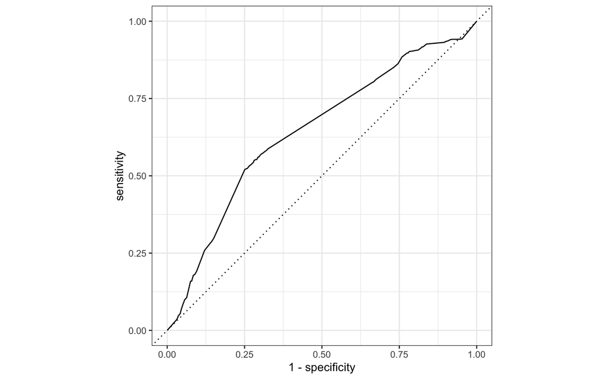

```r
dt_auc <-
  dt_res %>%
  collect_predictions(parameters=dt_best) %>%
  roc_curve(remote,.pred_Remote) %>%
  mutate(model="Decision Tree")
autoplot(dt_auc)
```

# A random forest model

Build the model:

```r
rf_mod <-
  rand_forest(mtry=tune(),min_n=tune(), trees=1000) %>%
  set_engine("ranger") %>%
  set_mode("classification")
```

Define the recipe :

```r
rf_recipe <- recipe(remote~., data = stack_train) %>%
  step_downsample(remote)
rf_recipe
```

```
## Data Recipe
##
## Inputs:
##
##       role #variables
##    outcome          1
##  predictor         20
##
## Operations:
##
## Down-sampling based on remote
```

Create the workflow:

```r
rf_workflow <-
  workflow() %>%
  add_model(rf_mod) %>%
  add_recipe(rf_recipe)
```

Train and tune the model:

```r
# show what will be tuned
rf_mod %>%
  parameters()
```

```
## Collection of 2 parameters for tuning
##
##  identifier  type    object
##        mtry  mtry nparam[?]
##       min_n min_n nparam[+]
##
## Model parameters needing finalization:
##    # Randomly Selected Predictors ('mtry')
##
## See `?dials::finalize` or `?dials::update.parameters` for more information.
```

```r
set.seed(345)
rf_res <-
  rf_workflow %>%
  tune_grid(val_set,
            grid=25,
            control=control_grid(save_pred = TRUE),
            metrics=metric_set(roc_auc))
```

```
## i Creating pre-processing data to finalize unknown parameter: mtry
```

Top 5 models from the 25 candidates:

```r
rf_res %>%
  show_best(metric="roc_auc")
```

```
## # A tibble: 5 × 8
##    mtry min_n .metric .estimator  mean     n std_err .config
##   <int> <int> <chr>   <chr>      <dbl> <int>   <dbl> <chr>
## 1     1    38 roc_auc binary     0.741     1      NA Preprocessor1_Model07
## 2     2    31 roc_auc binary     0.738     1      NA Preprocessor1_Model15
## 3     4    35 roc_auc binary     0.731     1      NA Preprocessor1_Model12
## 4     4    18 roc_auc binary     0.727     1      NA Preprocessor1_Model24
## 5     5    25 roc_auc binary     0.726     1      NA Preprocessor1_Model03
```

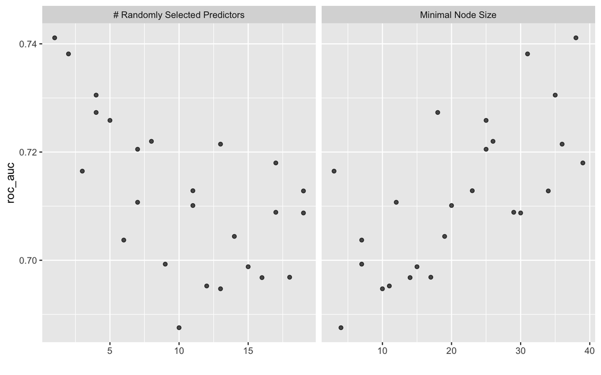

```r
autoplot(rf_res)
```

Lets select the best model according to the ROC AUC metric. Our final values are:

```r
rf_best <-
  rf_res %>%
  select_best(metric="roc_auc")
rf_best
```

```
## # A tibble: 1 × 3
##    mtry min_n .config
##   <int> <int> <chr>
## 1     1    38 Preprocessor1_Model07
```

To calculate the data needed to plot ROC curve, we use collect_predictions().

```r
rf_res %>%
  collect_predictions()
```

```
## # A tibble: 26,225 × 8
##    id         .pred_Remote `.pred_Not remote`  .row  mtry min_n remote  .config
##    <chr>             <dbl>              <dbl> <int> <int> <int> <fct>   <chr>
##  1 validation       0.742               0.258    10     9     7 Not re… Preproc…
##  2 validation       0.535               0.465    15     9     7 Not re… Preproc…
##  3 validation       0.590               0.410    18     9     7 Not re… Preproc…
##  4 validation       0.0961              0.904    24     9     7 Not re… Preproc…
##  5 validation       0.244               0.756    30     9     7 Not re… Preproc…
##  6 validation       0.412               0.588    34     9     7 Not re… Preproc…
##  7 validation       0.234               0.766    42     9     7 Not re… Preproc…
##  8 validation       0.760               0.240    43     9     7 Not re… Preproc…
##  9 validation       0.740               0.260    45     9     7 Not re… Preproc…
## 10 validation       0.762               0.238    48     9     7 Not re… Preproc…
## # … with 26,215 more rows
```

```r
rf_auc <-
  rf_res %>%
  collect_predictions(parameters=rf_best) %>%
                        roc_curve(remote,.pred_Remote) %>%
  mutate(model="Rndom Forest")
```

# Comparing the ROC curves for our top tuned models

Decision tree and random forest models:

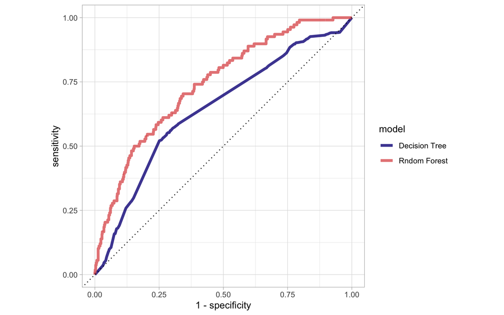

```r
bind_rows(rf_auc, dt_auc) %>%
  ggplot(aes(x = 1 - specificity, y = sensitivity, col = model)) +
  geom_path(lwd = 1.5, alpha = 0.8) +
  geom_abline(lty = 3) +
  coord_equal() +
  scale_color_viridis_d(option = "plasma", end = .6)+theme_light()
```